# Lecture 12: Story and Geometry

Nick Huntington-Klein

20 March, 2026

## Making it All Make Sense

- Now that we’ve spent some time on technical detail and how to get things working…
- Let’s bring it back to the point of all this, which is not to show off our R skills but to communicate effectively
- Don’t be so proud of your ability to code something up, or delighted at the ease of getting AI to produce something, that you forget to make the product good!

## Story and Data

- First off, remember our goals:
- Get across *an idea*
- Communicate *clearly*

## Story and Data

- It’s surprisingly common for people to forget the goal of getting across an idea
- Granted, this isn’t *always* necessary - some visualizations are just fun to look at even if we don’t care what they say. But that’s more like art than communication
- But in most settings we want to transmit an idea

## Story and Data

- What kind of ideas work well?
- You can think of a story as something you *learn* from the data. It reveals something about the world.
- There’s an important distinction between *showing the data* and *demonstrating an idea*
- Ask “what would I learn from viewing this visualization” and, crucially, “if I learned that thing, would I care?”

## Good Stories

Good stories:

- *Use data* to *broaden our understanding* of something, rather than using data to… show us data
- Provide an understanding that is interesting or actionable
- Don’t prompt responses of “why should I care about this?”

## Visualization Implies the Story

- Your decision of what to include or exclude, and what to compare or contrast, *implies a story*
- Make sure it’s the one you want to get across!
- Sometimes, you can just straight up say the idea in a title or annotation and just *demonstrate* with the visualization
- But a more satisfying (and convincing) result comes if the viewer comes to the conclusion on their own by viewing the viz
- Think “if I want people to come to this conclusion, what about my visualization points them there?”

## Stories Usually Need a Comparison

- Most data analyses that say something useful invite us to *compare* things
- Number A is higher than number B, or higher than it used to be, or more dispersed over here than over there
- Different geometries help us more easily show different kinds of comparisons

## Visualization Implies the Story

- What conclusion would this (fictional) graph make us come to?

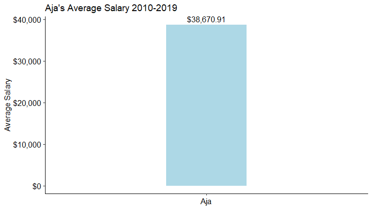

## Visualization Implies the Story

- How about this?

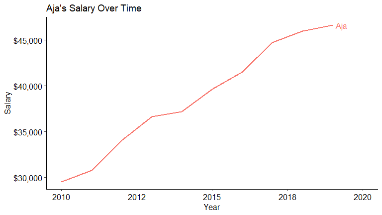

## Visualization Implies the Story

- And this one?

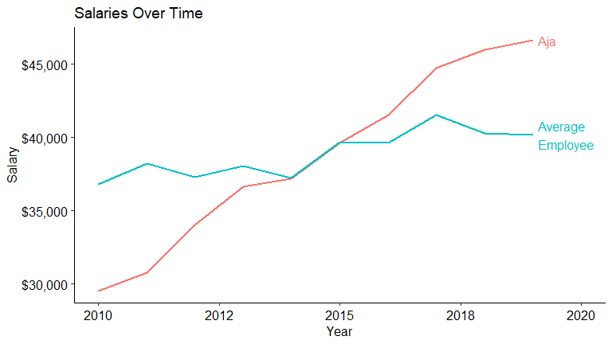

## Visualization Implies the Story

- If our goal was to show that Aja’s career has really taken off, which visualization works best?
- Is that a good story to try to tell?
- What does each invite us to compare?
- What might someone do with that information?

## Landing on the Story

- It’s very easy for us to write a graph that *demonstrates the thing we already know* but doesn’t *inspire that same idea in others*
- We need to do everything we can and get it all working right if that’s our goal!
- We talked about removing clutter - this is one reason why. Anything *else* on the graph is something besides your idea they can get distracted by

## Tips

- Don’t underestimate how difficult it is to get an idea across, especially indirectly by hoping someone sees *your intention* on a graph
- The best way to build intuition for how to do this is to *show other people your work and see if they come to the same conclusion you intended*
- Ask them what they think the graph means! Not just what it shows but what it *means*. The answer will often shock you

## Picking Geometries

- In the same vein, the choice of *geometry* has a lot to do with what stories can be effectively communicated and how they come across
- There are also some common errors made with certain geometries
- So let’s talk about them.
- We must ask: what does this geometry let us *compare* and *contrast*, and what do we *want* to compare and contrast?
- We can only evaluate a few but this will help us learn to evaluate them overall (and pick up some specific tips)

## In General

- If a geometry shows *lots of separate distinct objects* (like a bar graph), it wants you to compare those objects
- If a geometry draws *a continuous path* (like a line graph, or a cluster of points with a shape to it), it wants you to follow that path and see how it changes smoothly along some axis
- If a geometry shows *an area divided into many parts* (like a pie chart, treemap, or a stacked bar graph) it wants you to see how a whole object is divided up

## In General

- If a geometry represents *something real* (like a map) then it expects us to interpret it as that real thing
- If a geometry shows *differing colors, sizes, or shades* (like a lot of stuff), it’s expecting us to notice that something is *more* and compare it to something that is *less*
- If a geometry shows *crowded areas* and *sparse areas* (like a density plot, or clusters of points), it’s expecting us to see which areas are well-populated and which aren’t

## Bar Graphs

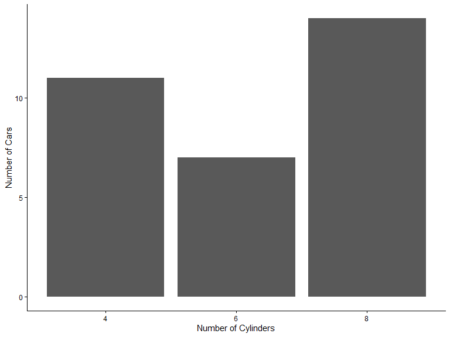

## Bar Graphs

Good for:

- Categorical x-axis variables
- For which you want to show a single count or summary statistic for each group
- Or possibly do a grouped bar chart (`position = 'dodge'`) to compare that summary statistic for that group within another grouping

(Tech tips: `geom_col()` lets you calculate bar height directly, `reorder()` in `aes()` lets you order the bars by size)

## Bar Graphs

Common mistakes:

- Overuse when other graphs (line graph, treemap) might be more appropriate
- Needing to compare values separated across long distances (next slide)
- Long labels on x-axis (try flipping the coordinates! `+coord_flip()`)
- Not using labeling to call attention to important parts
- Stacked bar charts outside a few good applications

## Bar Graph Mistakes Examples

- This requires us to do some visual gymnastics to compare the right stuff. A line graph would do this better.

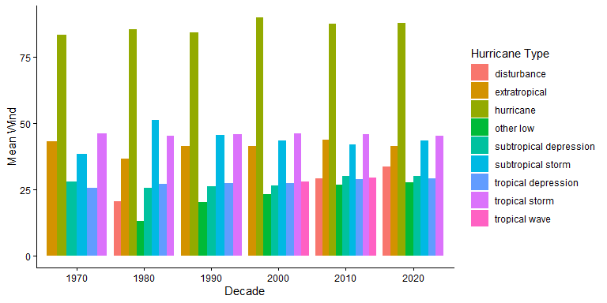

## Bar Graph Mistakes Examples

- This requires us to do some visual gymnastics to compare the right stuff. A line graph would do this better. Although this is still quite busy! Perhaps a revision could simplify.

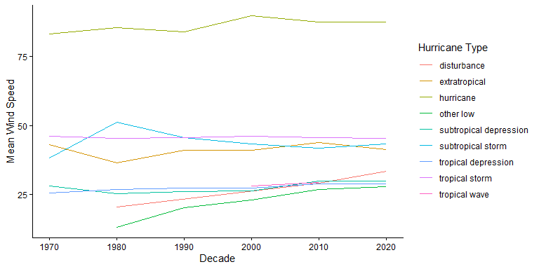

## Bar Graph Mistakes Examples

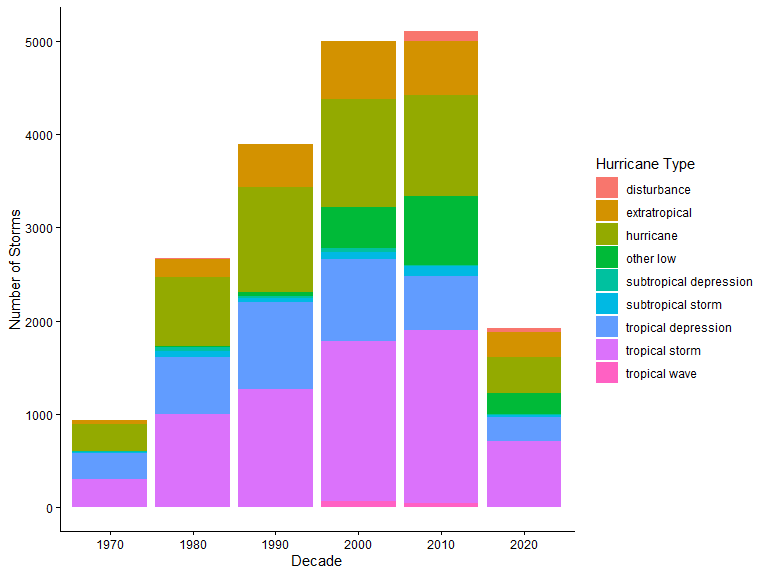

## Bar Chart Mistakes Examples

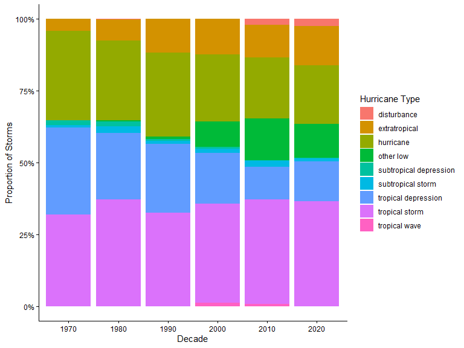

## Stacked Bar Charts

- Stacked bar charts make comparisons difficult
- You can track the size of the bottom category but not the rest
- Requires you to track a whole lot of information
- ONLY good for if you are ONLY interested in bottom category AND the total, but NOT any other categories
- Also, please please only apply this to outcome variables where it makes sense to stack (sum them) together. “Average price by category” doesn’t work.

## Stacked Bar Charts

- More broadly, a common mistake with stacked bar charts that I also see with pie charts, tree maps, and other geometries that divide an *area* up into *sections*:
- Dividing an area up into sections implies you are *dividing a whole into pieces* and also that you can *add the pieces back together to get the whole*
- This doesn’t work with stuff like averages! If you stack “average male income” on top of “average female income” you don’t get “average overall income”.

## Some Bar Graph Alternatives

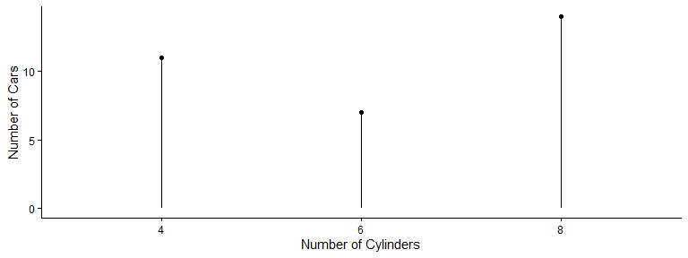

```r
# Good for taking up a bit less space, emphasizing the top
library(ggalt)
mtcars %>%  group_by(cyl) %>% summarize(N = n()) %>%
  ggplot(aes(x = factor(cyl), y = N)) +
  geom_lollipop() + theme_classic() +
  labs(x = 'Number of Cylinders',y = 'Number of Cars')
```

## Some Bar Graph Alternatives

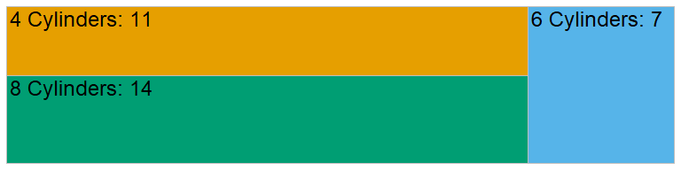

```r
# For just plain count-of-how-many, tree maps are way better at lots of categories
# Speaking of which, tree maps are better than pie charts almost 100% of the time
library(treemapify)
mtcars %>% group_by(cyl) %>% summarize(N = n()) %>%
  ggplot(aes(area = N, label = paste0(cyl,' Cylinders: ',N), fill = factor(cyl))) +
  geom_treemap() + geom_treemap_text() +
  guides(fill = 'none') + paletteer::scale_fill_paletteer_d('colorblindr::OkabeIto')
```

## Line Graphs

- Line graphs are good for one-to-one relationships between the x and y axis
- One x in, one y out $\rightarrow$ a bunch of x in, one line out
- Almost always x is in consistent discrete jumps (i.e. 1 2 3 not 1 3 100)
- Often, x is time
- Change over time
- When change occurred
- How different groups change (multiple line graphs on the same axes)

## Common Mistakes with Line Graphs

- Too many lines
- Lines that cross back and forth with each other and obscure each other a lot
- Legends (label the lines! It’s easy! `geom_text()`). Skip only if there are too many lines.
- Huge range in the y-axis (or too little range)
- Multiple y-axes
- An unordered x-axis (don’t use a line graph for bar graph jobs!) - remember, the line implies continuity!
- Curved lines can give illusion of continuity if it’s not there

## A Line Graph

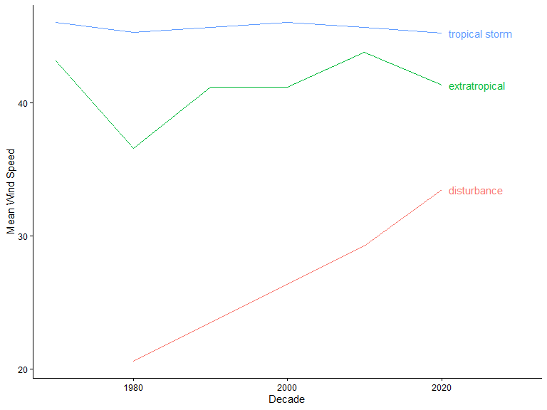

## Scatterplots

- Scatterplots show the relationship between two **continuous** variables, plotting every observation
- Use when that’s your goal, explaining how two variables move together AND you can see that relationship on the graph
- The shape of the relationship between them (positive, negative, null, U-shaped, etc.) should be clear
- Can also be handy for pointing out outliers (with annotation)
- Adding best-fit lines: when? If you want to refer to its slope, or if the shape is still *clear* but could maybe use a little help, or to contrast a couple of groups

## Scatterplots

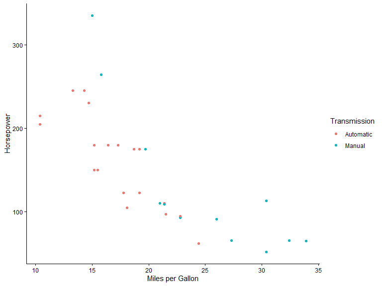

## Common Scatterplot Mistakes

- Expecting too much of the audience (scatterplots are easy to *understand* but it usually takes experience to *walk away with the story* from a scatterplot)
- Doing it with too many points - likely either a confusing mess, or at least some data will be obscured
- Non-continuous X or Y variables! `geom_jitter()` only helps a bit

## Too many points!

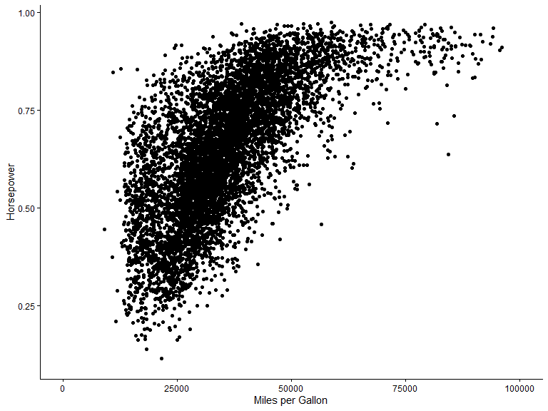

## Alternative for too many points

- Density coloring with `geom_bin2d`, although this requires some sophistication to read

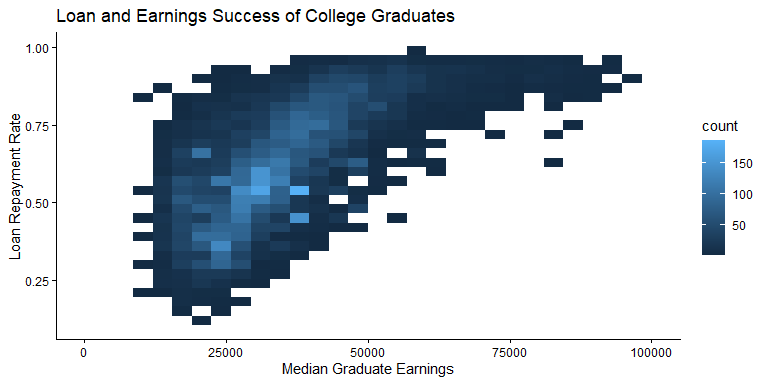

## Alternatives for Factors

- Factor vs. continuous: ridge or violin density plots (next section)
- Factor vs. factor: heatmaps as above, [balloon plots](https://rpkgs.datanovia.com/ggpubr/reference/ggballoonplot.html)

## Tables

- When individual values are *important*
- We want things to be easy to look up
- and CONCISE. Tables are inherently too messy so trim out everything

## Bad Table

|  | region | group | fertility | ppgdp | lifeExpF | pctUrban | infantMortality |
| --- | --- | --- | --- | --- | --- | --- | --- |
| Afghanistan | Asia | other | 5.968000 | 499.0 | 49.49000 | 23 | 124.535000 |
| Albania | Europe | other | 1.525000 | 3677.2 | 80.40000 | 53 | 16.561000 |
| Algeria | Africa | africa | 2.142000 | 4473.0 | 75.00000 | 67 | 21.458000 |
| American Samoa | NA | NA | NA | NA | NA | NA | 11.293887 |
| Angola | Africa | africa | 5.135000 | 4321.9 | 53.17000 | 59 | 96.191000 |
| Anguilla | Caribbean | other | 2.000000 | 13750.1 | 81.10000 | 100 | NA |
| Argentina | Latin Amer | other | 2.172000 | 9162.1 | 79.89000 | 93 | 12.337000 |
| Armenia | Asia | other | 1.735000 | 3030.7 | 77.33000 | 64 | 24.272000 |
| Aruba | Caribbean | other | 1.671000 | 22851.5 | 77.75000 | 47 | 14.687000 |
| Australia | Oceania | oecd | 1.949000 | 57118.9 | 84.27000 | 89 | 4.455000 |
| Austria | Europe | oecd | 1.346000 | 45158.8 | 83.55000 | 68 | 3.713000 |
| Azerbaijan | Asia | other | 2.148000 | 5637.6 | 73.66000 | 52 | 37.566000 |
| Bahamas | Caribbean | other | 1.877000 | 22461.6 | 78.85000 | 84 | 14.135000 |
| Bahrain | Asia | other | 2.430000 | 18184.1 | 76.06000 | 89 | 6.663000 |
| Bangladesh | Asia | other | 2.157000 | 670.4 | 70.23000 | 29 | 41.786000 |
| Barbados | Caribbean | other | 1.575000 | 14497.3 | 80.26000 | 45 | 12.284000 |
| Belarus | Europe | other | 1.479000 | 5702.0 | 76.37000 | 75 | 6.494000 |
| Belgium | Europe | oecd | 1.835000 | 43814.8 | 82.81000 | 97 | 3.739000 |
| Belize | Latin Amer | other | 2.679000 | 4495.8 | 77.81000 | 53 | 16.200000 |
| Benin | Africa | africa | 5.078000 | 741.1 | 58.66000 | 42 | 76.674000 |
| Bermuda | Caribbean | other | 1.760000 | 92624.7 | 82.30000 | 100 | NA |
| Bhutan | Asia | other | 2.258000 | 2047.2 | 69.84000 | 35 | 37.995000 |
| Bolivia | Latin Amer | other | 3.229000 | 1977.9 | 69.40000 | 67 | 40.684000 |
| Bosnia and Herzegovina | Europe | other | 1.134000 | 4477.7 | 78.40000 | 49 | 12.695000 |
| Botswana | Africa | africa | 2.617000 | 7402.9 | 51.34000 | 62 | 35.117000 |
| Brazil | Latin Amer | other | 1.800000 | 10715.6 | 77.41000 | 87 | 19.016000 |
| Brunei Darussalam | Asia | other | 1.984000 | 32647.6 | 80.64000 | 76 | 4.529000 |
| Bulgaria | Europe | other | 1.546000 | 6365.1 | 77.12000 | 72 | 9.149000 |
| Burkina Faso | Africa | africa | 5.750000 | 519.7 | 57.02000 | 27 | 70.958000 |
| Burundi | Africa | africa | 4.051000 | 176.6 | 52.58000 | 11 | 94.083000 |

[output cut: 183 more lines]

## Table Fixes

- Tables for a non-specialist audience should only have a few variables. Usually 1-2 “identifying” rows (state, year, rank, etc.) and 1-2 “data” rows
- Make sure the numbers look nice, no eight digits after the decimal; add things like % signs and $ signs.
- In R you can often do this with the **scales** package

## Easy to Read

- Short: Nobody likes to scroll through an enormous table
- Consider not showing ALL the data here, maybe just a “top ten” if that’s relevant
- If all the data really is necessary, try to make its presentation shorter and encourage scrolling while everything else stays in place
- Consider “striping” to make different rows easy to distinguish with `kableExtra::kable_styling(bootstrap_options = ‘striped’)
- More coloring and customization with `ggtexttable` in **ggpubr** (note this makes the table as an image) or the highly flexible **gt** package

## Easy to Read

Top Five Opportunities for Expansion

|  | Country | Per-Capita GDP | Percent Urban |
| --- | --- | --- | --- |
| Bermuda | Bermuda | $92,624.70 | 100% |
| Cayman Islands | Cayman Islands | $57,047.90 | 100% |
| Macao | Macao | $49,990.20 | 100% |
| Singapore | Singapore | $43,783.10 | 100% |
| Hong Kong | Hong Kong | $31,823.70 | 100% |

- This could be even better - generally you want as few borders as possible (but RMarkdown is not cooperating)

## Hall of Shame

- Pie charts: not *the worst* but rarely better than a bar chart or treemap. We just don’t distinguish angles that well. Works best with ONLY one category you care about, and with percentages labeled. At least people understand them
- Word clouds: I have no idea what anyone would learn from one of these. Looks pretty?
- [Bubble charts](https://help.tableau.com/current/pro/desktop/en-us/buildexamples_bubbles.htm). Carries little info in a lot of space, and in very hard-to-see ways (compare circle areas?). Tableau recommends them for some reason.

## Let’s evaluate

How about density plots?

- `geom_density()` and `geom_histogram`, `geom_dotplot`, extras like `geom_violin` and the **ggridges** package
- What would these work well for and what would they not?
- What problems might we run into?

## Let’s evaluate

- How about heatmaps on actual maps? Same question

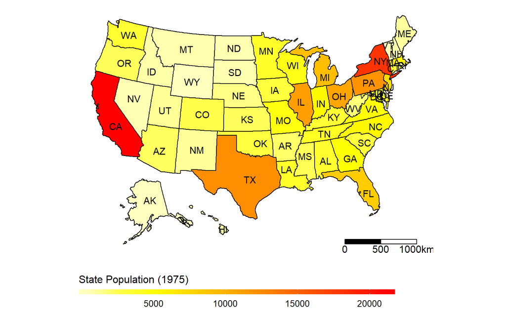

Map-based state heatmap

## Let’s evaluate

- And what would a version like this solve for us?

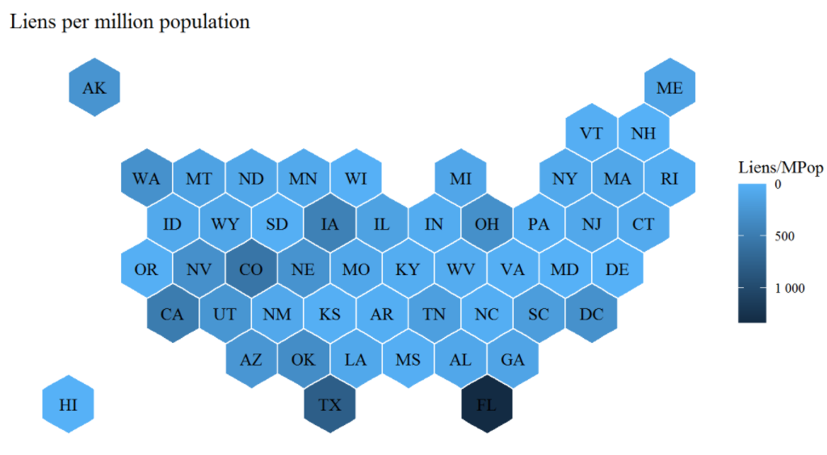

Hex-based state map

## Gallery

- There are LOTS of other options out there. For example, paired plots, Sankey diagrams, path diagrams, etc. etc.
- We can see the [gallery](https://exts.ggplot2.tidyverse.org/gallery/) but our key here is being able to evaluate whether a geometry works for what *we want to get across* and can do it in a clear way

## Practice

- Download this file of robocall complaints to the FCC: https://www.kaggle.com/fcc/robocall-complaints
- Think of a basic story (it’s ok if it’s not stellar)
- Think about the best geometry to tell that story
- Sketch a graph to tell that story as clearly as possible
- If you have time, make it
- You can load it with `read_csv()` and, if necessary, use `ymd` in **lubridate** to make the date a date

## Downloadable Geometries

- There are so, so many **ggplot2** geometries available
- Way too many to cover - see the [ggplot2 extension gallery](https://exts.ggplot2.tidyverse.org/gallery/) in addition to the base-**ggplot2** cheat sheet from last time
- I will go over some popular ones. Google package names for more detailed explanations
- We won’t go deeply into how to use these, this is more to show you they exist and an example so you can look further yourself if you’re interested

## geom_text to geom_repel

- We covered geom_text last time
- But the text gets in the way! How did I handle this in that `mtcars` graph I just did?

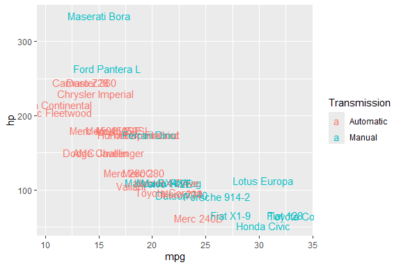

## geom_text_repel

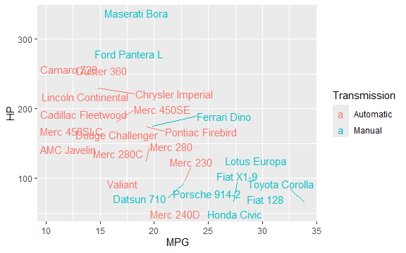

```r
library(ggrepel); data(mtcars)
mtcars <- mtcars %>%
  mutate(Transmission = factor(am, labels = c('Automatic','Manual')),
         CarName = row.names(mtcars))
ggplot(mtcars, aes(x = mpg, y = hp, color = Transmission, label = CarName)) +
  geom_text_repel() + labs(x = 'MPG',y='HP')
```

## ggmap

- **ggplot2** has *extensive* mapping capabilities
- Including straightforward-ish map *animations* with the **tmap** package
- Also see libraries **choloropleth**, **tigris**, **tmap**, **sf**, **fiftystater**

## gganimate

- The **gganimate** package makes it fairly straightforward to animate your graphs
- Take a graph and use a `transition_` command to have it assign one axis to *time*
- Make sure this actually adds something! This limits where the graph can be shown

## gganimate

```r
library(gganimate)
data(gapminder)
options(gganimate.dev_args = list(width = 650, height = 400))
p <- ggplot(gapminder,
       aes(x = gdpPercap, y = lifeExp, color = continent)) +
  geom_point() +
  scale_x_log10() +
  labs(x = "GDP per Capita (log scale)", y = "Life Expectancy",
       title = "GDP and Life Expectancy by Country, 1952-2007",
       color = 'Continent') +
  transition_time(year))
animate(p,nframes = 200,end_pause = 30)
```

## gganimate

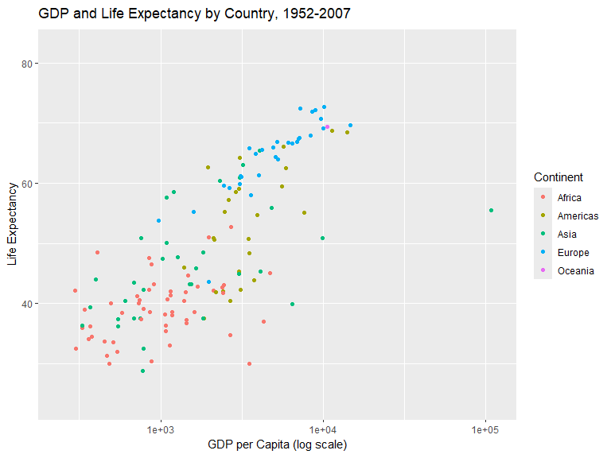